# Predicting income

Jose Luis diaz Pulgar

2023-03-24

# Predicting Income with Social Data.

The Panel Survey of Income Data is the longest running longitudinal household survey in the world. Survey responses related to social, economic, and health outcomes have been collected from the families and their descendants since 1968.

This dataset is widely used by social scientists to investigate the relationship between individual characteristics, like gender or age, and broader socioeconomic outcomes like education achievement and lifetime income. In this project, you’ll have the chance to use PSID data and linear regression to predict the labor-derived income of survey respondents based on the following set of variables:

- **`gender`**: the gender, female-identifying, male-identifying, or other, of a respondent
- **`age`**: the age of the respondent
- **`married`**: the marital status, unmarried, married, or divorced, of a respondent
- **`employed`**: the employment status of the respondent at the time of survey collection
- **`educated_in_us`**: whether the respondent went to primary school in the United Statues
- **`highest_degree`**: the highest educational degree obtained by the respondent
- **`education_years`**: the total number of years of formal education completed by the respondent
- **`labor_income`**: the yearly income earned by the respondent from a salary or hourly employment

Unlike other data science methods, linear regression models will allow us to not only predict the value of a respondent’s income, but provide information on how a variable impacts respondent income. Let’s dive into the social patterns that underly Americans’ incomes!

## Clean and check data assumptions.

```r
# load packages and data
library(ggplot2)
library(dplyr)
library(modelr)
psid <- read.csv("psid_2017.csv")
```

1. checkout the structure of our dataset.

```r
head(psid,10)
```

|  | X | gender | age | married | employed | educated_in_us | highest_degree | education_years | labor_income |
| --- | --- | --- | --- | --- | --- | --- | --- | --- | --- |
| 1 | 1 | 2 | 59 | 0 | disabled | 1 | no college | 12 | 0 |
| 2 | 2 | 2 | 57 | 0 | employed | 1 | no college | 12 | 0 |
| 3 | 3 | 2 | 43 | 0 | disabled | 1 | no college | 12 | 0 |
| 4 | 4 | 2 | 44 | 0 | NA | 9 | no college | 99 | 0 |
| 5 | 5 | 1 | 42 | 0 | employed | 1 | no college | 12 | 0 |
| 6 | 6 | 2 | 30 | 1 | employed | 1 | no college | 12 | 0 |
| 7 | 7 | 2 | 27 | 0 | employed | 1 | no college | 12 | 0 |
| 8 | 8 | 1 | 27 | 0 | employed | 1 | no college | 12 | 0 |
| 9 | 9 | 2 | 25 | 0 | unemployed | 1 | no college | 12 | 0 |
| 10 | 10 | 1 | 21 | 0 | NA | 0 | no college | 0 | 0 |

```r
str(psid)
```

```
## 'data.frame':    26445 obs. of  9 variables:
##  $ X              : int  1 2 3 4 5 6 7 8 9 10 ...
##  $ gender         : int  2 2 2 2 1 2 2 1 2 1 ...
##  $ age            : int  59 57 43 44 42 30 27 27 25 21 ...
##  $ married        : int  0 0 0 0 0 1 0 0 0 0 ...
##  $ employed       : chr  "disabled" "employed" "disabled" NA ...
##  $ educated_in_us : int  1 1 1 9 1 1 1 1 1 0 ...
##  $ highest_degree : chr  "no college" "no college" "no college" "no college" ...
##  $ education_years: int  12 12 12 99 12 12 12 12 12 0 ...
##  $ labor_income   : int  0 0 0 0 0 0 0 0 0 0 ...
```

2. Plot a bar graph. data age

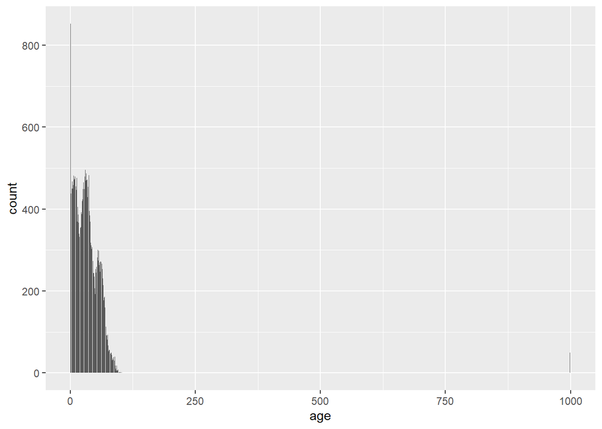

```r
age_dist <- ggplot(data = psid, aes(x=age)) +
  geom_bar()
age_dist
```

3. We are interested in predicting the labor income of survey respondents, it would be reasonable to filter our data so that it only includes respondents of working age, roughly between 18 and 75.

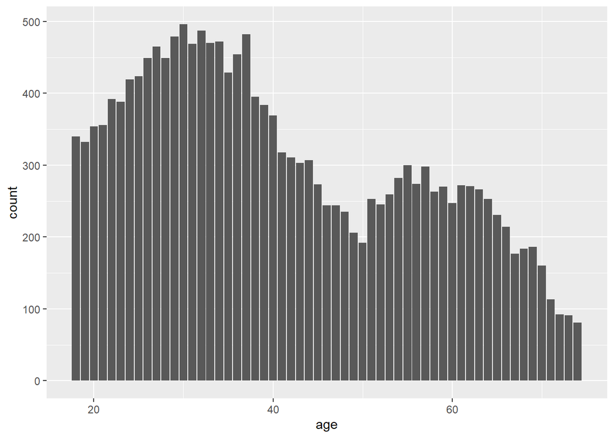

```r
psid_clean <- psid%>%filter(age>=18 & age<75)
age_dist_clean <- ggplot(data = psid_clean, aes(x=age)) +
  geom_bar()
age_dist_clean
```

4. Draw a boxplot of education years to find outliers.

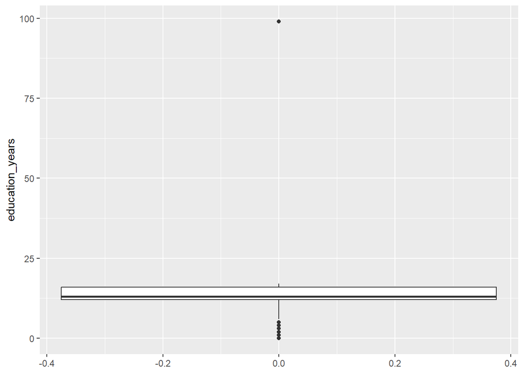

```r
educ_dist <- psid_clean%>%
  ggplot(aes(y = education_years)) +
  geom_boxplot()

# view plot
educ_dist
```

5. some of the values in our observed data do not make much sense. Limit education years between 5 and 25 years

```r
psid_clean <- psid_clean%>%filter(education_years > 5 & education_years < 25)
```

6. Boxplot of labor income

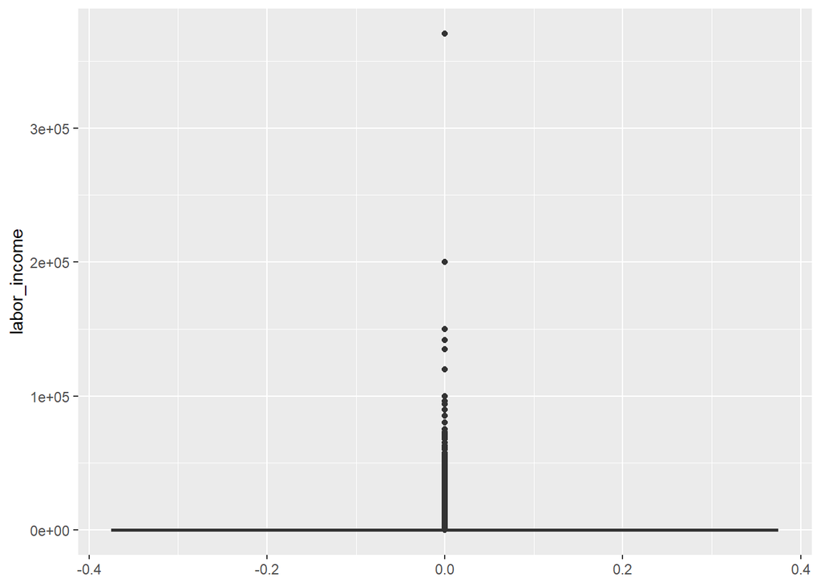

```r
income_dist <- ggplot(data=psid_clean, aes(y=labor_income))+
  geom_boxplot()
income_dist
```

7. Using summary for a better interpretation of the column `labor_income`

```r
summary(psid_clean$labor_income)
```

```
##    Min. 1st Qu.  Median    Mean 3rd Qu.    Max.
##       0       0       0    1778       0  370500
```

8. Creating a scatterplot of average income by age.

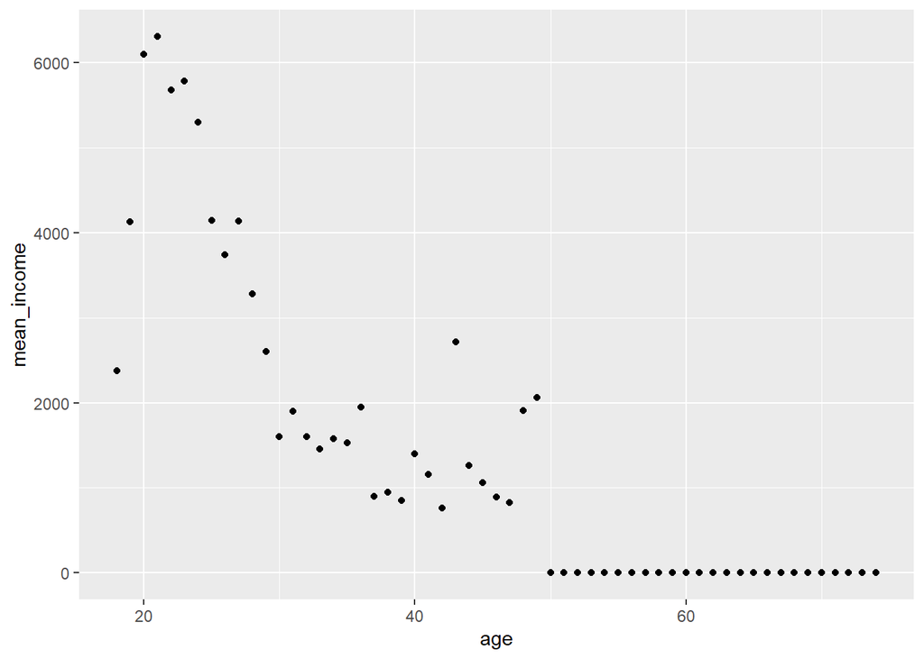

```r
mean_income_by_age <- psid_clean%>%
  group_by(age) %>%
  summarise(mean_income = mean(labor_income)) %>%
  ggplot(aes(age, mean_income)) +
  geom_point()
mean_income_by_age
```

It seems like those 50 years are older are much more likely to have zero income. While this skew will effect our model, given that up until the age of 50 there appears to be a roughly linear relationship between `age` and `labor_income`, it is still valid to use linear regression to model this dataset.

## Build model and assess fit.

9. Defining train set and test set and building the model.

```r
# Defining a seed
set.seed(123)

sample <- sample(c(TRUE, FALSE), nrow(psid_clean), replace = T, prob = c(0.6,0.4))

# Defining train and test sets

train <- psid_clean[sample,]
test <- psid_clean[!sample,]

# Building the model: education_years on labor_income

model <- lm(labor_income~education_years, data = train)

# Results
summary(model)
```

```
##
## Call:
## lm(formula = labor_income ~ education_years, data = train)
##
## Residuals:
##    Min     1Q Median     3Q    Max
##  -2414  -1912  -1745  -1577 148423
##
## Coefficients:
##                 Estimate Std. Error t value Pr(>|t|)
## (Intercept)      2916.42     462.60   6.304 3.02e-10 ***
## education_years   -83.70      33.52  -2.497   0.0125 *
## ---
## Signif. codes:  0 '***' 0.001 '**' 0.01 '*' 0.05 '.' 0.1 ' ' 1
##
## Residual standard error: 7486 on 9710 degrees of freedom
## Multiple R-squared:  0.0006419,  Adjusted R-squared:  0.000539
## F-statistic: 6.237 on 1 and 9710 DF,  p-value: 0.01253
```

10. Let’s compare our model against an LOESS smoother to see where our model predictions differ most substantially from the average observed value.

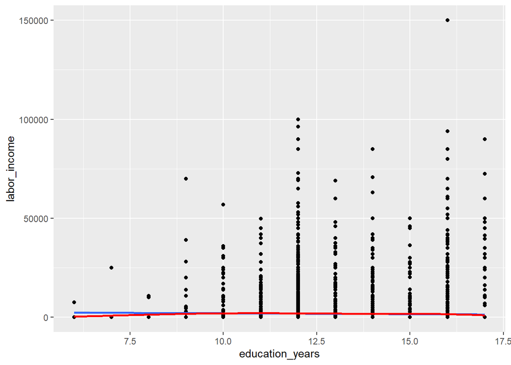

```r
# plot against LOESS model
plot <- ggplot(data=train, aes(education_years, labor_income)) +
  geom_point() +
  geom_smooth(method = "lm") +
  geom_smooth(se = FALSE, color = "red")

# view plot
plot
```

It looks like our model is quite similar to the average of observed values as plotted by the LOESS.

11. Obtaining r_squared

```r
r_sq <- summary(model)$r.squared * 100
r_sq
```

```
## [1] 0.06418749
```

```r
sprintf("Based on a simple linear regression model, we have determined that %s percent of the variation in respondent income can be predicted by a respondent's education level.", r_sq)
```

```
## [1] "Based on a simple linear regression model, we have determined that 0.0641874935897278 percent of the variation in respondent income can be predicted by a respondent's education level."
```

## Build comparison model and analyze results.

12. Build a second model, `model_2`, which regresses `education_years`, `age`, and `gender` on `labor_income`.

```r
model2 <- lm(labor_income~education_years + age + gender, data = train)

summary(model2)
```

```
##
## Call:
## lm(formula = labor_income ~ education_years + age + gender, data = train)
##
## Residuals:
##    Min     1Q Median     3Q    Max
##  -4649  -2690  -1599     99 148560
##
## Coefficients:
##                 Estimate Std. Error t value Pr(>|t|)
## (Intercept)     7553.904    522.589  14.455  < 2e-16 ***
## education_years  -27.822     32.932  -0.845    0.398
## age             -100.487      5.008 -20.065  < 2e-16 ***
## gender          -845.419    149.343  -5.661 1.55e-08 ***
## ---
## Signif. codes:  0 '***' 0.001 '**' 0.01 '*' 0.05 '.' 0.1 ' ' 1
##
## Residual standard error: 7323 on 9708 degrees of freedom
## Multiple R-squared:  0.04396,    Adjusted R-squared:  0.04367
## F-statistic: 148.8 on 3 and 9708 DF,  p-value: < 2.2e-16
```

```r
r_sq2 <- summary(model2)$r.squared * 100
sprintf("Based on a simple linear regression model, we have determined that %s percent of the variation in respondent income can be predicted by a respondent's education level, age and gender.", r_sq2)
```

```
## [1] "Based on a simple linear regression model, we have determined that 4.39643599406759 percent of the variation in respondent income can be predicted by a respondent's education level, age and gender."
```

14. Let’s also provide a graphic representation of our model_2 fit by plotting the observed and predicted values of labor income using add_predictions() from the modelr` package:

Using our test data, add a call to add_predictions(), passing in model_2 Add a call to ggplot(), passing age and labor_income as parameters to aes() Add a call to geom_point() to plot our observed values Add a call to geom_line(), explicitly setting in pred as a y value in aes(), and passing in color = “blue” as a parameter.

```r
train2 <- test%>%add_predictions(model2)
train2
```

|  | X | gender | age | married | employed | educated_in_us | highest_degree | education_years | labor_income | pred |
| --- | --- | --- | --- | --- | --- | --- | --- | --- | --- | --- |
| 2 | 2 | 2 | 57 | 0 | employed | 1 | no college | 12 | 0 | -198.5443011 |
| 4 | 5 | 1 | 42 | 0 | employed | 1 | no college | 12 | 0 | 2154.1747228 |
| 5 | 6 | 2 | 30 | 1 | employed | 1 | no college | 12 | 0 | 2514.5962350 |
| 8 | 9 | 2 | 25 | 0 | unemployed | 1 | no college | 12 | 0 | 3017.0296676 |
| 11 | 19 | 1 | 35 | 1 | unemployed | 1 | no college | 12 | 0 | 2857.5815285 |
| 13 | 22 | 1 | 24 | 0 | employed | 1 | no college | 12 | 16147 | 3962.9350802 |
| 16 | 25 | 2 | 51 | 1 | disabled | 1 | no college | 12 | 0 | 404.3758181 |
| 20 | 30 | 2 | 52 | 1 | disabled | 1 | no college | 13 | 0 | 276.0666374 |
| 21 | 32 | 1 | 45 | 2 | employed | 1 | no college | 12 | 10000 | 1852.7146633 |
| 22 | 33 | 2 | 44 | 1 | employed | 1 | no college | 12 | 0 | 1107.7826237 |

[output cut: 6282 more lines]

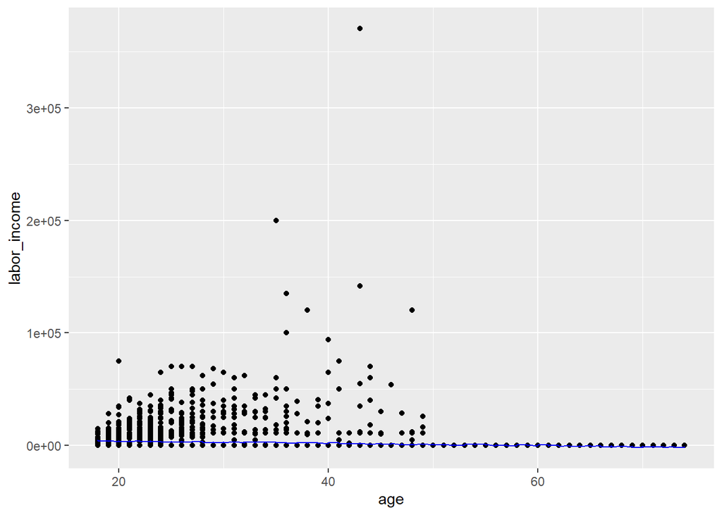

```r
plot <- ggplot(data=train2, aes(age, labor_income))+
  geom_point()+
  geom_line(aes(y=pred), color="blue")

plot
```

15. Extract the value of the education_years `coefficent` and assign the result to a variable called `education_coefficent`.

```r
education_coefficent <- model2$coefficients[2]

sprintf("Based on a multiple linear regression model of education, age, and gender, for every additional year of formal education, the average American resident's income increases by $%s.", education_coefficent)
```

```
## [1] "Based on a multiple linear regression model of education, age, and gender, for every additional year of formal education, the average American resident's income increases by $-27.8224941019814."
```